# **Reproducible Research: Peer Assessment 1**

## Loading and preprocessing the data

Load the data and Process/transform the data (if necessary) into a format suitable for your analysis.

```r
unzip(zipfile='activity.zip')
dt <- read.csv('activity.csv')
```

## What is mean total number of steps taken per day?

Calculate the total number of steps taken per day, Make a histogram of the total number of steps taken each day

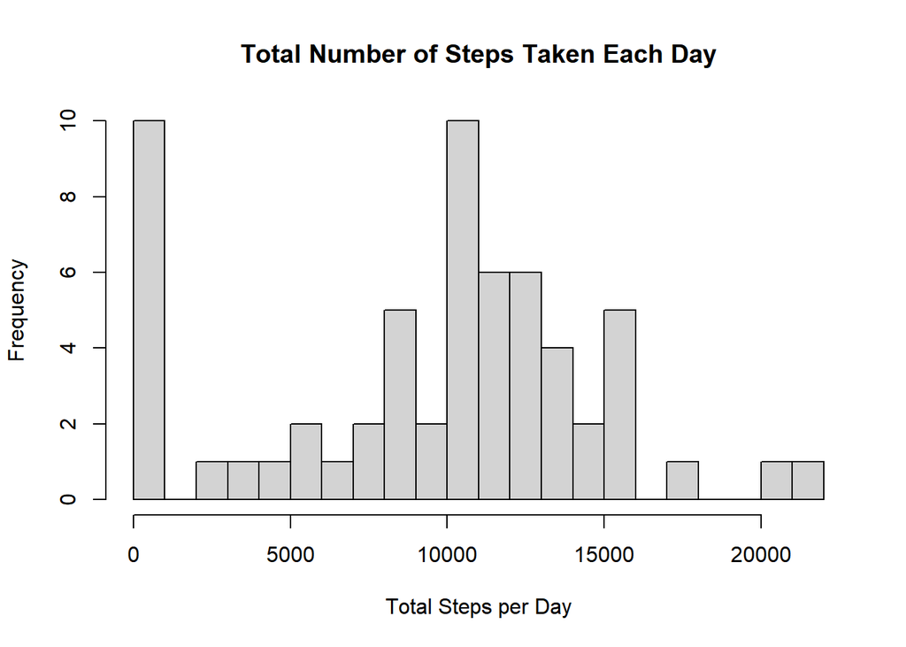

```r
stepsum <- with(dt, tapply(steps,date,FUN=sum,na.rm=TRUE))
hist(stepsum, breaks=20, xlab='Total Steps per Day', main='Total Number of Steps Taken Each Day')
```

Calculate and report the mean and median of the total number of steps taken per day.

```r
mean(stepsum,na.rm=TRUE)
```

```
## [1] 9354.23
```

```r
median(stepsum,na.rm=TRUE)
```

```
## [1] 10395
```

## What is the average daily activity pattern?

Make a time series plot of the 5-minute interval (x-axis) and the average number of steps taken, averaged across all days (y-axis).

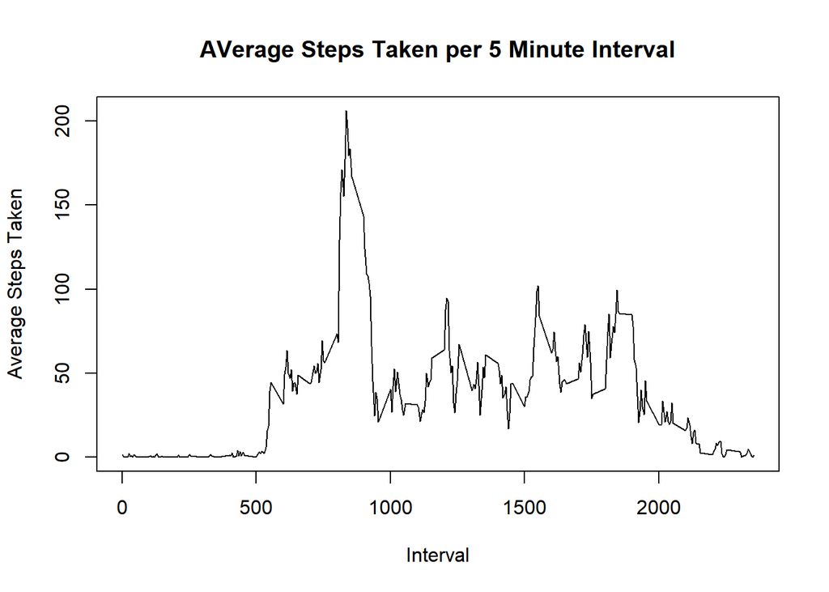

```r
avestep <- aggregate(x=dt$steps,by=list(dt$interval),FUN=mean,na.rm=TRUE)
with(avestep, plot(Group.1,x,type='l',xlab='Interval',ylab='Average Steps Taken',main='AVerage Steps Taken per 5 Minute Interval'))
```

Which 5-minute interval, on average across all the days in the dataset, contains the maximum number of steps?

```r
avestep[which.max(avestep$x),]
```

```
##     Group.1        x
## 104     835 206.1698
```

## Imputing missing values

Calculate and report the total number of missing values in the dataset.

```r
sum(is.na(dt))
```

```
## [1] 2304
```

Create a new dataset that is equal to the original dataset but with the missing data filled in with the mean value.

```r
meanreplace <- function(x)
  replace(x, is.na(x), mean(x, na.rm = TRUE))
avestep.new<- dt %>% group_by(interval) %>% mutate(steps= meanreplace(steps))
head(avestep.new)
```

```
## # A tibble: 6 x 3
## # Groups:   interval [6]
##    steps date       interval
##    <dbl> <chr>         <int>
## 1 1.72   2012-10-01        0
## 2 0.340  2012-10-01        5
## 3 0.132  2012-10-01       10
## 4 0.151  2012-10-01       15
## 5 0.0755 2012-10-01       20
## 6 2.09   2012-10-01       25
```

Make a histogram of the total number of steps taken each day.

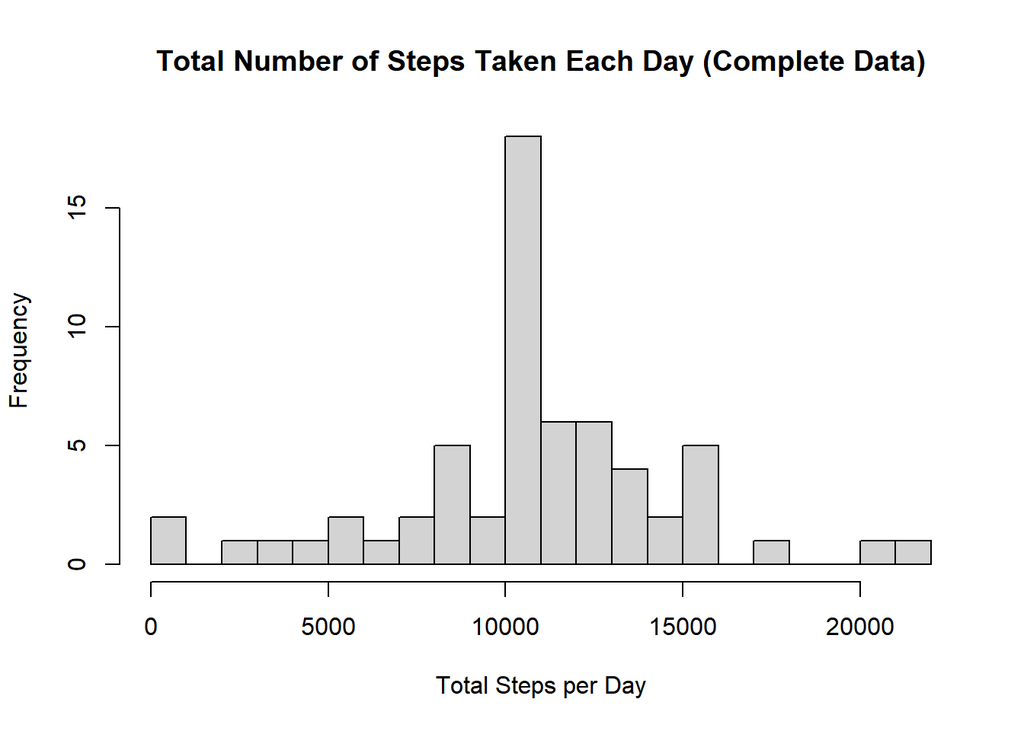

```r
stepsum.new <- with(avestep.new, tapply(steps,date,FUN=sum,na.rm=TRUE))
hist(stepsum.new, breaks=20, xlab='Total Steps per Day', main='Total Number of Steps Taken Each Day (Complete Data)')
```

Calculate and report the mean and median total number of steps taken per day.

```r
mean(stepsum.new,na.rm=TRUE)
```

```
## [1] 10766.19
```

```r
median(stepsum.new,na.rm=TRUE)
```

```
## [1] 10766.19
```

After the mean is added to the NA values, it was seen that the mean and median increased to **10766.19**.

## Are there differences in activity patterns between weekdays and weekends?

Create a new factor variable in the dataset with two levels – “weekday” and “weekend” indicating whether a given date is a weekday or weekend day.

```r
dt$date <- as.Date(dt$date)
dt$week <- ifelse(weekdays(dt$date) %in% c("Saturday", "Sunday"), "weekend", "weekday")
```

Make a panel plot containing a time series plot of the 5-minute interval (x-axis) and the average number of steps taken, averaged across all weekday days or weekend days (y-axis).

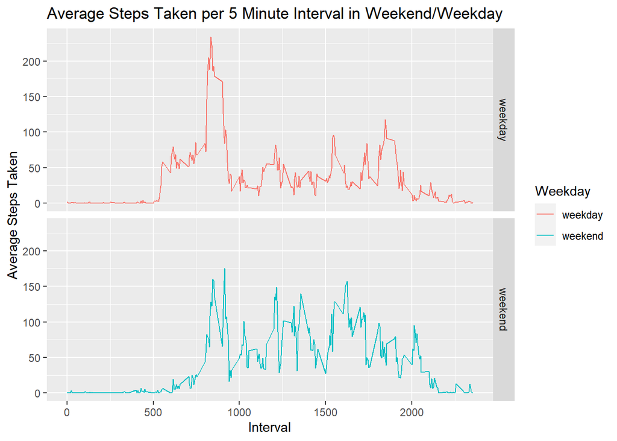

```r
avestepweek <- aggregate(x=dt$steps,by=list(dt$interval,dt$week),FUN=mean,na.rm=TRUE)
ggplot(avestepweek,aes(x=Group.1,y=x,color=Group.2))+geom_line()+facet_grid(Group.2 ~.)+labs(x='Interval',y='Average Steps Taken',title='Average Steps Taken per 5 Minute Interval in Weekend/Weekday',col='Weekday')
```